# lab-1-stat3925

Mason

27/02/2022

# Question 1

In this question we store the data in a variable called **data**. we then use the **ts.plot()** function to plot data. Since it’s difficult to change the x-values on the x axis with the **ts.plot()** function, we revert back to the normal **plot()** function to do this. We then change the title to an appropriate title and note that this plot has non-constant mean and variance with a downward linear trend. It also looks to be seasonal…

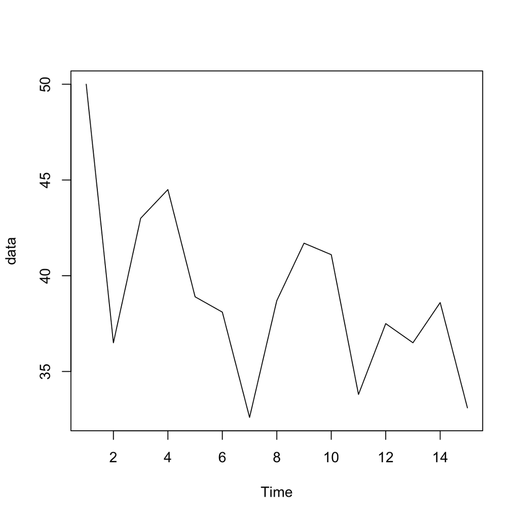

```r
data = c(50.0,36.5,43.0,44.5,38.9,38.1,32.6,38.7,41.7,41.1,33.8,37.5,36.5,38.6,33.1)
ts.plot(data)
```

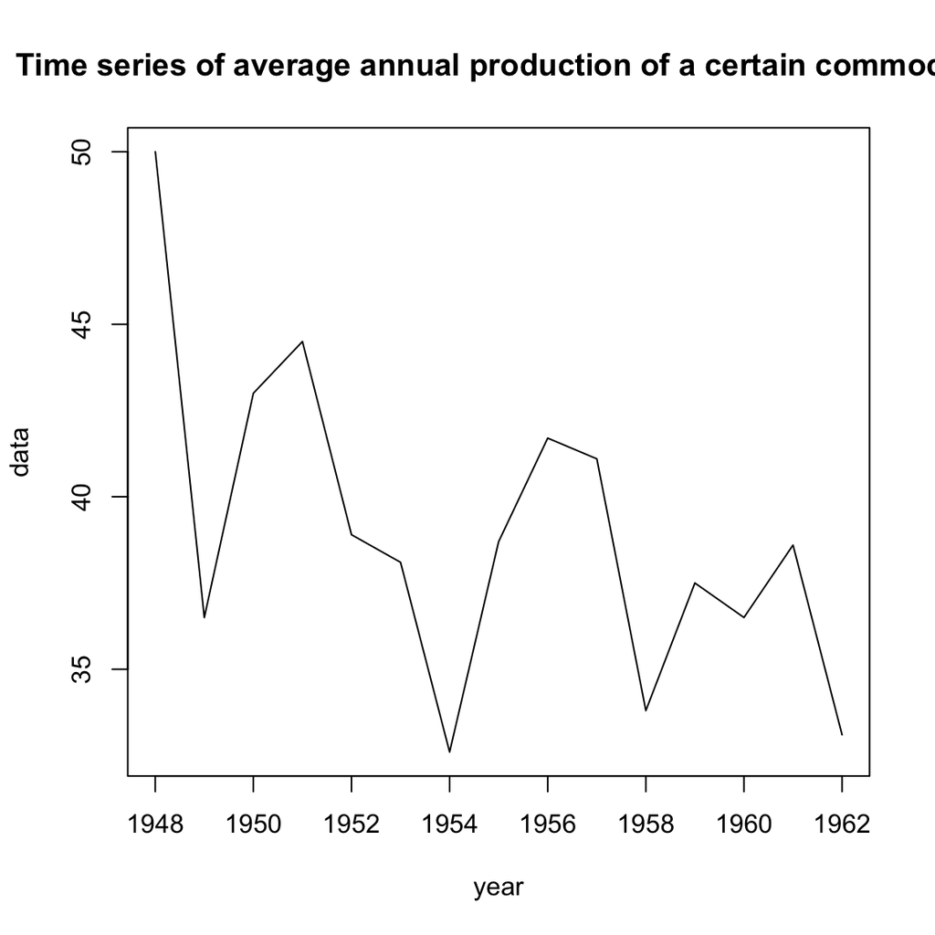

```r
x_names = 1948:1962
plot(x_names, data, type = "l", lty = 1, xlab = "year")
title("Time series of average annual production of a certain commodity")
```

# Question 2

Consider the time series in Q1. Find the following moving averages for this time series.

1. 5 year moving averages and store in f1. Recall that the weights are (1/5,1/5,1/5,1/5,1/5)

```r
f1 = filter(data, rep(1/5, 5))
```

2. 4 year centred moving averages and store in f2. Recall that the weights are (1/8,1/4,1/4,1/4,1/8)

```r
weights = c(1/(2*4), rep(1/4, 4 - 1), 1/(2*4))
f2 = filter(data, weights)
```

# Question 3

(Ref Q2 above): Graph the moving averages (ma) in (i) and (ii) together with the original time series using:

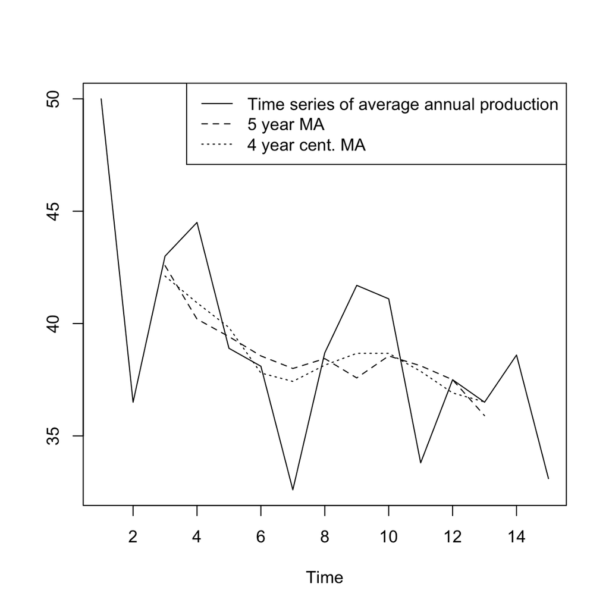

```r
ts.plot(cbind(data,f1,f2), lty = c(1, 2, 3))
legend("topright", c("Time series of average annual production",
                     "5 year MA", "4 year cent. MA"), lty=c(1,2,3))
```

# Question 4

Three sets of time series data (from course notes, P2) are attached to analyse. Copy and paste the set 1 on your R window. Obtain the time series plot of this data, label the axes and give its title. Comment on this time series.

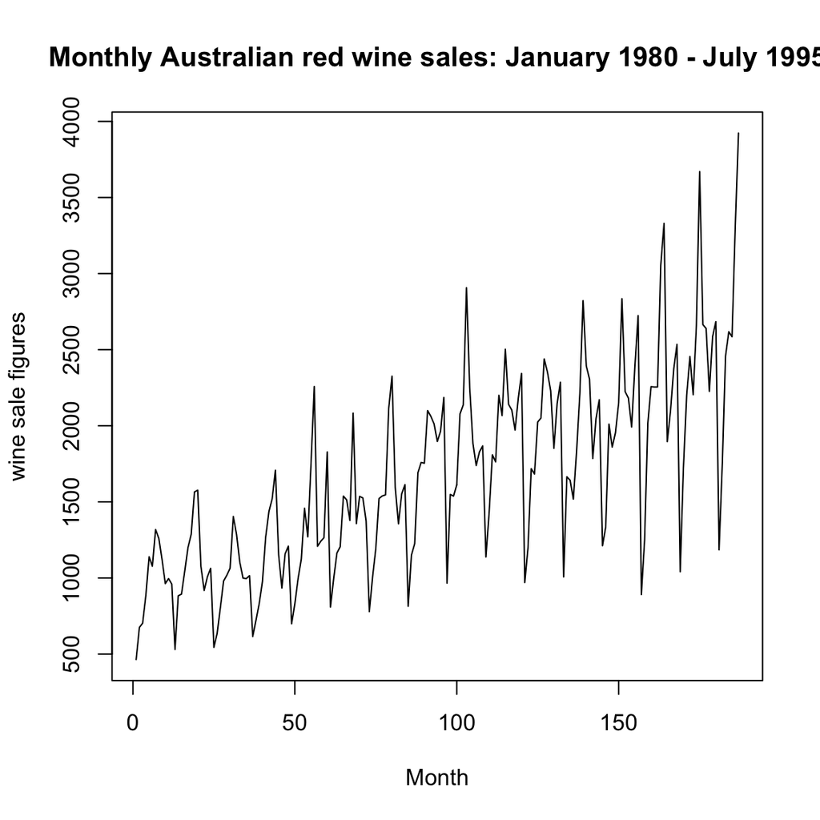

```r
data1 = c(464, 675, 703, 887, 1139, 1077, 1318, 1260, 1120, 963, 996, 960, 530, 883, 894, 1045, 1199, 1287, 1565, 1577, 1076,
918, 1008, 1063, 544, 635, 804, 980, 1018, 1064, 1404, 1286, 1104, 999, 996, 1015, 615, 722, 832, 977, 1270, 1437, 1520,
1708, 1151, 934, 1159, 1209, 699, 830, 996, 1124, 1458, 1270, 1753, 2258, 1208, 1241, 1265, 1828, 809, 997, 1164, 1205,
1538, 1513, 1378, 2083, 1357, 1536, 1526, 1376, 779, 1005, 1193, 1522, 1539, 1546, 2116, 2326, 1596, 1356, 1553, 1613,
814, 1150, 1225, 1691, 1759, 1754, 2100, 2062, 2012, 1897, 1964, 2186, 966, 1549, 1538, 1612, 2078, 2137, 2907, 2249,
1883, 1739, 1828, 1868, 1138, 1430, 1809, 1763, 2200, 2067, 2503, 2141, 2103, 1972, 2181, 2344, 970, 1199, 1718, 1683,
2025, 2051, 2439, 2353, 2230, 1852, 2147, 2286, 1007, 1665, 1642, 1518, 1831, 2207, 2822, 2393, 2306, 1785, 2047, 2171,
1212, 1335, 2011, 1860, 1954, 2152, 2835, 2224, 2182, 1992, 2389, 2724, 891, 1247, 2017, 2257, 2255, 2255, 3057, 3330,
1896, 2096, 2374, 2535, 1041, 1728, 2201, 2455, 2204, 2660, 3670, 2665, 2639, 2226, 2586, 2684, 1185, 1749, 2459, 2618,
2585, 3310, 3923)
ts.plot(data1, xlab = "Month", ylab = "wine sale figures")
title("Monthly Australian red wine sales: January 1980 - July 1995")
```

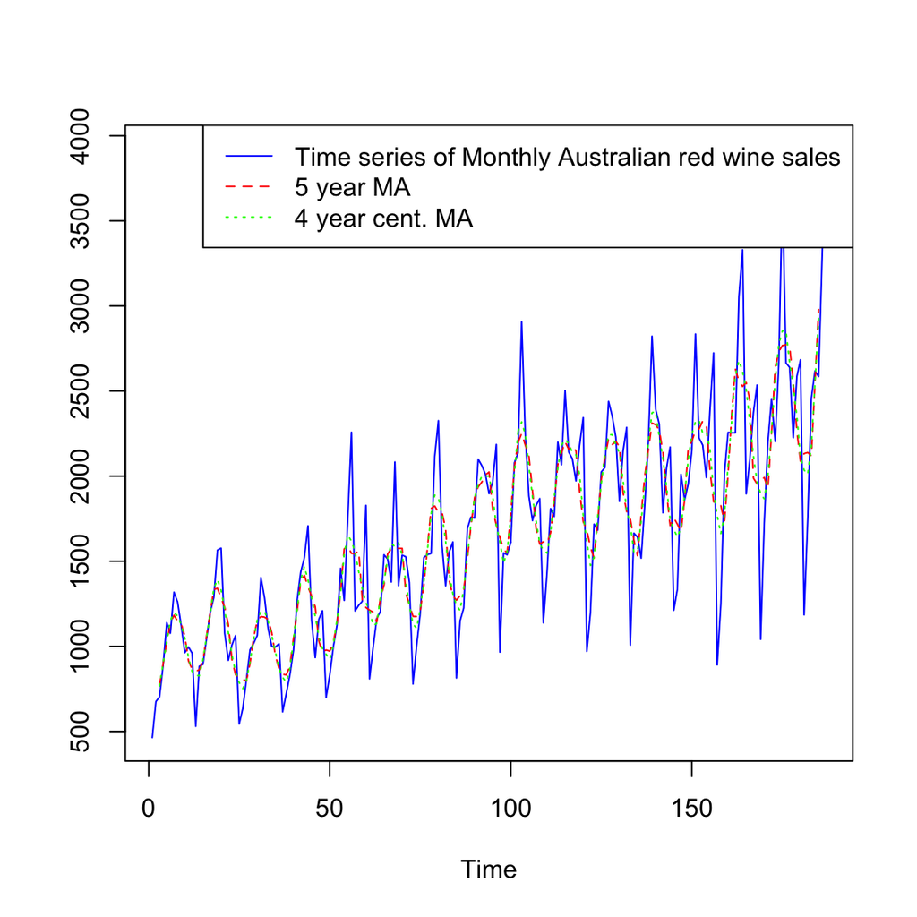

```r
f1 = filter(data1, rep(1/5, 5))
weights = c(1/(2*4), rep(1/4, 4 - 1), 1/(2*4))
f2 = filter(data1, weights)
ts.plot(cbind(data1,f1,f2), lty = c(1, 2, 3), col = c("blue", "red", "green"))
legend("topright", c("Time series of Monthly Australian red wine sales",
                     "5 year MA", "4 year cent. MA"), lty=c(1,2,3), col = c("blue", "red", "green"))
```

A preliminary look at this data shows that the mean and variance are not stable. There is an upward linear trend. There seems to be some periodicity here.

# Question 5

Repeat the above steps for the remaining two time series data sets.

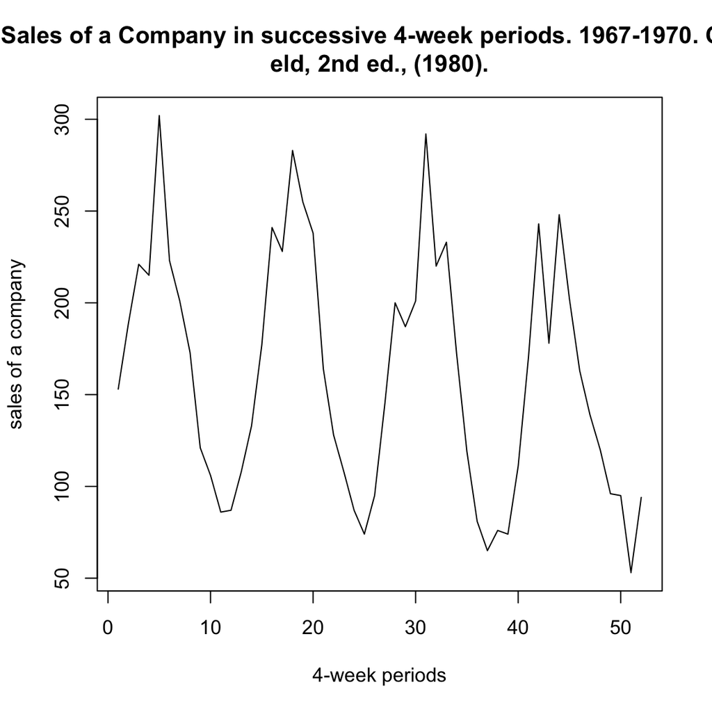

```r
data2 = c(153, 189, 221, 215, 302, 223, 201, 173, 121, 106, 86, 87, 108, 133, 177, 241, 228, 283, 255, 238, 164, 128, 108, 87, 74, 95,
145, 200, 187, 201, 292, 220, 233, 172, 119, 81, 65, 76, 74, 111, 170, 243, 178, 248, 202, 163, 139, 120, 96, 95, 53, 94)

ts.plot(data2, xlab = "4-week periods", ylab = "sales of a company")
title("Sales of a Company in successive 4-week periods. 1967-1970. Chat
eld, 2nd ed., (1980).")
```

[figure not shown]

```r
f1 = filter(data2, rep(1/5, 5))
weights = c(1/(2*4), rep(1/4, 4 - 1), 1/(2*4))
f2 = filter(data2, weights)
ts.plot(cbind(data2,f1,f2), lty = c(1, 2, 3), col = c("blue", "red", "green"))
legend("topright", c("Time series of Monthly Australian red wine sales",
                     "5 year MA", "4 year cent. MA"), lty=c(1,2,3), col = c("blue", "red", "green"))
```

The mean doesn’t seem stable but the variance does. We also see that there is a downward linear trend and that there is a strong seasonal component.

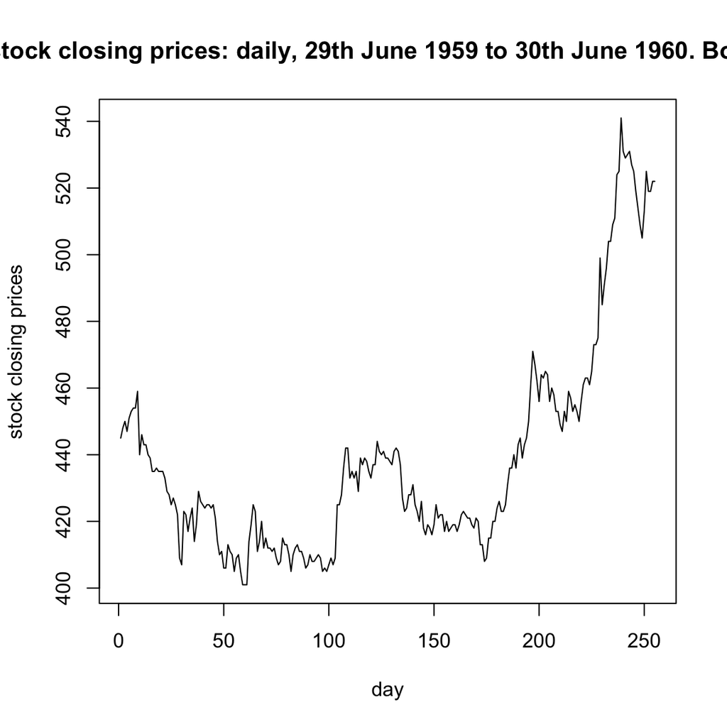

```r
data3 = c(445, 448, 450, 447, 451, 453, 454, 454, 459, 440, 446, 443, 443, 440, 439, 435, 435, 436, 435, 435, 435, 433, 429, 428,
425, 427, 425, 422, 409, 407, 423, 422, 417, 421, 424, 414, 419, 429, 426, 425, 424, 425, 425, 424, 425, 421, 414, 410, 411,
406, 406, 413, 411, 410, 405, 409, 410, 405, 401, 401, 401, 414, 419, 425, 423, 411, 414, 420, 412, 415, 412, 412, 411, 412,
409, 407, 408, 415, 413, 413, 410, 405, 410, 412, 413, 411, 411, 409, 406, 407, 410, 408, 408, 409, 410, 409, 405, 406, 405,
407, 409, 407, 409, 425, 425, 428, 436, 442, 442, 433, 435, 433, 435, 429, 439, 437, 439, 438, 435, 433, 437, 437, 444, 441,
440, 441, 439, 439, 438, 437, 441, 442, 441, 437, 427, 423, 424, 428, 428, 431, 425, 423, 420, 426, 418, 416, 419, 418, 416,
419, 425, 421, 422, 422, 417, 420, 417, 418, 419, 419, 417, 419, 422, 423, 422, 421, 421, 419, 418, 421, 420, 413, 413, 408,
409, 415, 415, 420, 420, 424, 426, 423, 423, 425, 431, 436, 436, 440, 436, 443, 445, 439, 443, 445, 450, 461, 471, 467, 462,
456, 464, 463, 465, 464, 456, 460, 458, 453, 453, 449, 447, 453, 450, 459, 457, 453, 455, 453, 450, 456, 461, 463, 463, 461,
465, 473, 473, 475, 499, 485, 491, 496, 504, 504, 509, 511, 524, 525, 541, 531, 529, 530, 531, 527, 525, 519, 514, 509, 505,
513, 525, 519, 519, 522, 522)


ts.plot(data3, xlab = "day", ylab = "stock closing prices")
title("IBM common stock closing prices: daily, 29th June 1959 to 30th June 1960. Box & Jenkins (1976)")
```

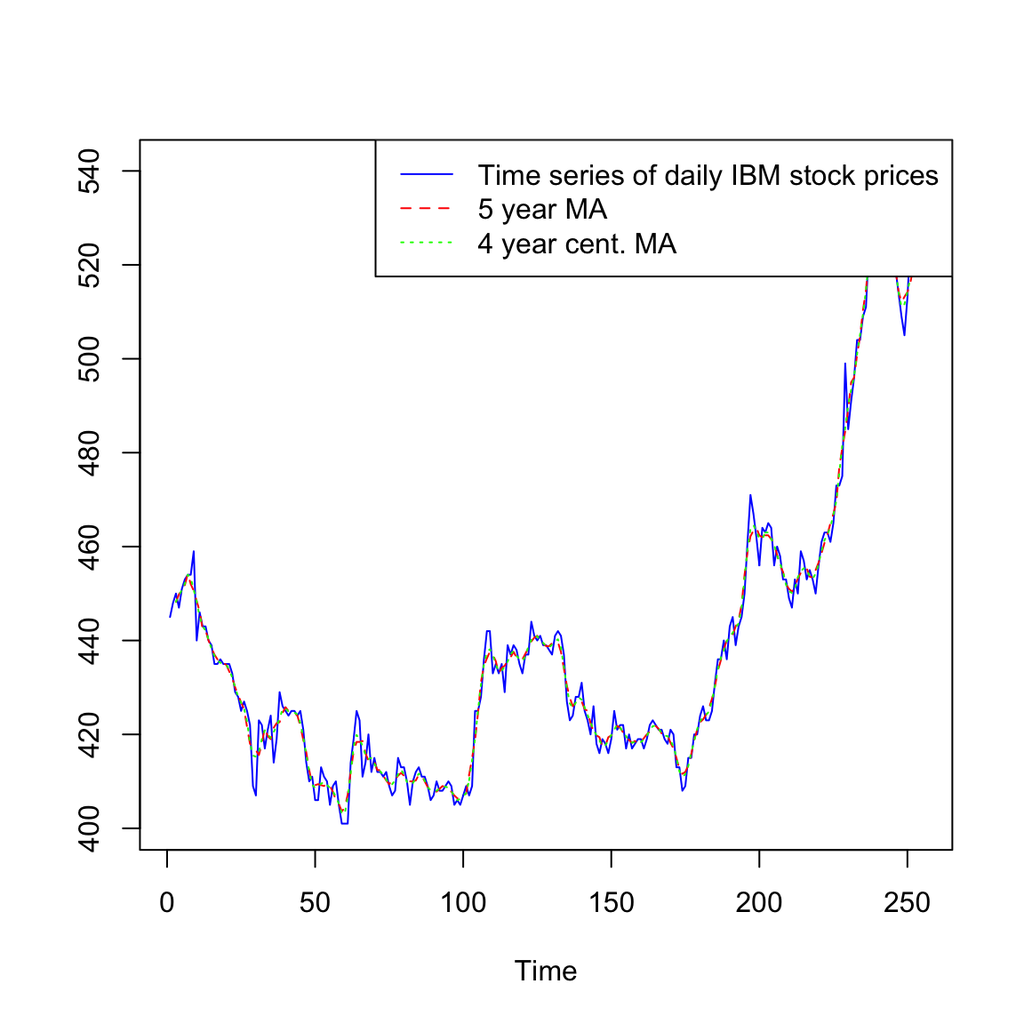

```r
f1 = filter(data3, rep(1/5, 5))
weights = c(1/(2*4), rep(1/4, 4 - 1), 1/(2*4))
f2 = filter(data3, weights)
ts.plot(cbind(data3,f1,f2), lty = c(1, 2, 3), col = c("blue", "red", "green"))
legend("topright", c("Time series of daily IBM stock prices",
                     "5 year MA", "4 year cent. MA"), lty=c(1,2,3), col = c("blue", "red", "green"))
```

# Question 6

Obtain the acf values at lags 1 and 2, r1 and r2 for the time series in Q2(b) (Tutorial). Find r using the data in table in Q2(c). Comment on r and r1.